# Modelos Lineares Generalizados(MLG) ¶

joseferson da silva barreto e Antônio Victor Alves Silva

2022-10-12

# Objetivo

# Metodologia

### Definindo o Problema de Negócio

Nosso objetivo é construir um modelo de regressão generalizado que seja capaz de explicar quais características influenciam na precificação do automovel. A variável a ser prevista é um valor numérico que representa o preço de cada automovel observado. Para cada automóvel temos diversas variáveis explanatórias. Sendo assim, podemos buscar resolver este problema utilizando MLG.

### Definindo o Dataset

Este conjunto de dados consiste em dados do Anuário Automotivo da Ward de 1985. Aqui estão as fontes

Fontes:

1. 1985 Modelo de Importação de Carro e Especificações de Caminhão, Anuário Automotivo de 1985 Ward.
2. Personal Auto Manuals, Insurance Services Office, 160 Water Street, Nova York, NY 10038
3. Insurance Collision Report, Insurance Institute for Highway Safety, Watergate 600, Washington, DC 20037

Esse conjunto de dados consiste em três tipos de entidades: (a) a especificação de um automóvel em termos de várias características, (b) sua classificação de risco de seguro atribuída, (c) suas perdas normalizadas em uso em comparação com outros carros. A segunda classificação corresponde ao grau em que o automóvel é mais arriscado do que seu preço indica. Os carros recebem inicialmente um símbolo de fator de risco associado ao seu preço. Então, se for mais arriscado (ou menos), esse símbolo é ajustado movendo-o para cima (ou para baixo) na escala. Os atuários chamam esse processo de “simbolização”. Um valor de +3 indica que o automóvel é arriscado, -3 que provavelmente é bastante seguro.

O terceiro fator é o pagamento de perda média relativa por ano de veículo segurado. Este valor é normalizado para todos os automóveis dentro de uma determinada classificação de tamanho (pequeno de duas portas, carrinhas, desporto/especialidade, etc…), e representa a perda média por automóvel por ano.

Nota: Vários dos atributos no banco de dados podem ser usados como um atributo de “classe”.

- total de variáveis: 26
- total de observações :205

# Introdução

[figure not shown]

O primeiro meio de transporte a fazer uso de um motor a gasolina para se locomover foi um automóvel que continha somente três rodas e foi criado no ano de 1885 por um alemão de nome Karl Benz.A partir de então teve início a corrida pela produção e venda de automóveis, iniciada por uma empresa francesa conhecida pelo nome de Panhard et Levassor. No ano de 1892, o conhecido Henry Ford fabricou seu primeiro carro, o Ford, na América do Norte.Estima-se que a quantidade de autóveis no Brasil já ultrapassa a casa dos 11 milhões de veículos, segundo o senado, Dados da Secretaria Nacional de Trânsito do Ministério da Infraestrutura indicam haver mais de 3,5 milhões de caminhões em circulação no Brasil e, desse total, cerca de 26% dos veículos possuem mais de 30 anos de fabricação, a expectativa é que esse número aumente ainda mais nós próximos anos. Neste material buscaremos criar um modelo capaz de explicar quais fatores influenciar no preço do automóvel, para este fim sera utilizado os modelos lineares generalizados.

Os modelos lineares Generalizados são utilizados quando utilizar os modelos clássicos que pressupoem que os dados seguem uma distribuição normal e principalmente onde temos dados que segue uma base de dados discretos . O princípio do GLM é pegar uma família de distribuições ao ínves de uma única distribuição que no nosso caso será a famíla exponencial , ou sejá , ao ínves de trabalhar apenas com a normal , trabalhamos com várias distribuições : gamma,expenencial,poisson ,binomial,binomial negativa,weibell. Um estudo de regressão busca,essencialmente,associar uma variável **Y** (denominada variável dependente)a uma outra variável **X** (denominada variável explanatória ou variável independente ).

## Partes de um MLG

1. $Y_{i} \sim p(y | \theta) \rightarrow E(y_{i}) = \mu_{i}$
2. $n_{i} = g(\mu_{i})$
3. $n_{i} = \beta_{0} + \beta_{1} *x_{I}$

# Conhecendo o Nossos Dados

## Análise Exploratória

O ponta pé inicial de qualquer análise é a análise exploratória, com ela começas a entender a grandeza dos nossos dados e os seus comportamentos, dessa forma, vamos carregar os pacotes necessários e executar a análise exploratória:

```r
library(tidyverse)
library(DT)
library(readxl)

rm(list = ls())
dados<-read.table("dados.txt",sep = ",",header = TRUE)
```

Vamos verificar se nosso conjunto de dados pussui valores ausentes, caso tenhamos, teremos que remover essas observações

```r
sum(dados[!complete.cases(dados),])
```

```
## [1] 0
```

Como podemos ver o nosso conjunto de dados não apresentou nenhum valor faltante, logo, podemos prosseguir da forma que está.

### Observando a Grandeza dos Nossos Dados

Para verificar a grandeza dos nossos dados vamos utilizar o seguinte comando:

```r
glimpse(dados)
```

```
## Rows: 205
## Columns: 26
## $ symboling         <int> 3, 3, 1, 2, 2, 2, 1, 1, 1, 0, 2, 0, 0, 0, 1, 0, 0, 0…
## $ normalized.losses <chr> "?", "?", "?", "164", "164", "?", "158", "?", "158",…
## $ make              <chr> "alfa-romero", "alfa-romero", "alfa-romero", "audi",…
## $ fuel.type         <chr> "gas", "gas", "gas", "gas", "gas", "gas", "gas", "ga…
## $ aspiration        <chr> "std", "std", "std", "std", "std", "std", "std", "st…
## $ num.of.doors      <chr> "two", "two", "two", "four", "four", "two", "four", …
## $ body.style        <chr> "convertible", "convertible", "hatchback", "sedan", …
## $ drive.wheels      <chr> "rwd", "rwd", "rwd", "fwd", "4wd", "fwd", "fwd", "fw…
## $ engine.location   <chr> "front", "front", "front", "front", "front", "front"…
## $ wheel.base        <dbl> 88.6, 88.6, 94.5, 99.8, 99.4, 99.8, 105.8, 105.8, 10…
## $ length            <dbl> 168.8, 168.8, 171.2, 176.6, 176.6, 177.3, 192.7, 192…
## $ width             <dbl> 64.1, 64.1, 65.5, 66.2, 66.4, 66.3, 71.4, 71.4, 71.4…
## $ height            <dbl> 48.8, 48.8, 52.4, 54.3, 54.3, 53.1, 55.7, 55.7, 55.9…
## $ curb.weight       <int> 2548, 2548, 2823, 2337, 2824, 2507, 2844, 2954, 3086…
## $ engine.type       <chr> "dohc", "dohc", "ohcv", "ohc", "ohc", "ohc", "ohc", …
## $ num.of.cylinders  <chr> "four", "four", "six", "four", "five", "five", "five…
## $ engine.size       <int> 130, 130, 152, 109, 136, 136, 136, 136, 131, 131, 10…
## $ fuel.system       <chr> "mpfi", "mpfi", "mpfi", "mpfi", "mpfi", "mpfi", "mpf…
## $ bore              <chr> "3.47", "3.47", "2.68", "3.19", "3.19", "3.19", "3.1…
## $ stroke            <chr> "2.68", "2.68", "3.47", "3.40", "3.40", "3.40", "3.4…
## $ compression.ratio <dbl> 9.00, 9.00, 9.00, 10.00, 8.00, 8.50, 8.50, 8.50, 8.3…
## $ horsepower        <chr> "111", "111", "154", "102", "115", "110", "110", "11…
## $ peak.rpm          <chr> "5000", "5000", "5000", "5500", "5500", "5500", "550…
## $ city.mpg          <int> 21, 21, 19, 24, 18, 19, 19, 19, 17, 16, 23, 23, 21, …
## $ highway.mpg       <int> 27, 27, 26, 30, 22, 25, 25, 25, 20, 22, 29, 29, 28, …
## $ price             <chr> "13495", "16500", "16500", "13950", "17450", "15250"…
```

Como podemos ver a maioria das variáveis não estão no formato adequado,vamos ter que converte-las para fatores as que são referentes a fatores e numericos a referente a valores númericos

### Transformações de Variáveis

Vamos utilizar a função **mutate_if** para colocar a condição de transformação das colunas, por exemplo , no primeiro código abaixo as culanas de dados da coluna 3 a coluna 9 que são do tipo character serão convertidas para factor , os demais códigos abaixo seguem as mesmas linhas de raciocínio.

```r
dados$stroke[dados$stroke == "?"] <- "NA"
dados$bore[dados$bore == "?"] <- "NA"
dados$normalized.losses[dados$normalized.losses == "?"] <- "NA"
dados$num.of.doors[dados$num.of.doors == "?"] <- "NA"
dados$engine.size[dados$engine.size == "l"] <- "NA"
dados$price[dados$price == "?"] <- "NA"

dados[3:9]<-dados[3:9] %>% mutate_if(is.character,as.factor)

dados[15:16]<-dados[15:16] %>% mutate_if(is.character,as.factor)



dados[18]<-dados[18] %>% mutate_if(is.character,as.factor)


dados[20]<-dados[20] %>% mutate_if(is.character,as.factor)



dados<-dados %>% mutate_if(is.character,as.numeric)
```

Vamos observar os nossos dados

```r
library(gt)
# dados |> datatable(
#           rownames = FALSE,
#           options = list(
#             columnDefs = list(list(className = 'dt-center', targets = 0:4))
#             )
#           )






dados |> head(10) |> gt()
```

| symboling | normalized.losses | make | fuel.type | aspiration | num.of.doors | body.style | drive.wheels | engine.location | wheel.base | length | width | height | curb.weight | engine.type | num.of.cylinders | engine.size | fuel.system | bore | stroke | compression.ratio | horsepower | peak.rpm | city.mpg | highway.mpg | price |
| --- | --- | --- | --- | --- | --- | --- | --- | --- | --- | --- | --- | --- | --- | --- | --- | --- | --- | --- | --- | --- | --- | --- | --- | --- | --- |
| 3 | NA | alfa-romero | gas | std | two | convertible | rwd | front | 88.6 | 168.8 | 64.1 | 48.8 | 2548 | dohc | four | 130 | mpfi | 3.47 | 2.68 | 9.0 | 111 | 5000 | 21 | 27 | 13495 |
| 3 | NA | alfa-romero | gas | std | two | convertible | rwd | front | 88.6 | 168.8 | 64.1 | 48.8 | 2548 | dohc | four | 130 | mpfi | 3.47 | 2.68 | 9.0 | 111 | 5000 | 21 | 27 | 16500 |
| 1 | NA | alfa-romero | gas | std | two | hatchback | rwd | front | 94.5 | 171.2 | 65.5 | 52.4 | 2823 | ohcv | six | 152 | mpfi | 2.68 | 3.47 | 9.0 | 154 | 5000 | 19 | 26 | 16500 |
| 2 | 164 | audi | gas | std | four | sedan | fwd | front | 99.8 | 176.6 | 66.2 | 54.3 | 2337 | ohc | four | 109 | mpfi | 3.19 | 3.40 | 10.0 | 102 | 5500 | 24 | 30 | 13950 |
| 2 | 164 | audi | gas | std | four | sedan | 4wd | front | 99.4 | 176.6 | 66.4 | 54.3 | 2824 | ohc | five | 136 | mpfi | 3.19 | 3.40 | 8.0 | 115 | 5500 | 18 | 22 | 17450 |
| 2 | NA | audi | gas | std | two | sedan | fwd | front | 99.8 | 177.3 | 66.3 | 53.1 | 2507 | ohc | five | 136 | mpfi | 3.19 | 3.40 | 8.5 | 110 | 5500 | 19 | 25 | 15250 |
| 1 | 158 | audi | gas | std | four | sedan | fwd | front | 105.8 | 192.7 | 71.4 | 55.7 | 2844 | ohc | five | 136 | mpfi | 3.19 | 3.40 | 8.5 | 110 | 5500 | 19 | 25 | 17710 |
| 1 | NA | audi | gas | std | four | wagon | fwd | front | 105.8 | 192.7 | 71.4 | 55.7 | 2954 | ohc | five | 136 | mpfi | 3.19 | 3.40 | 8.5 | 110 | 5500 | 19 | 25 | 18920 |
| 1 | 158 | audi | gas | turbo | four | sedan | fwd | front | 105.8 | 192.7 | 71.4 | 55.9 | 3086 | ohc | five | 131 | mpfi | 3.13 | 3.40 | 8.3 | 140 | 5500 | 17 | 20 | 23875 |
| 0 | NA | audi | gas | turbo | two | hatchback | 4wd | front | 99.5 | 178.2 | 67.9 | 52.0 | 3053 | ohc | five | 131 | mpfi | 3.13 | 3.40 | 7.0 | 160 | 5500 | 16 | 22 | NA |

Podemos perceber que após as transformações temos a presença de valores ausentes,teremos que tratar esses valores ausentes

### Trantando valores ausentes nas variáveis númericas

```r
# symboling é fator ,mas vai permanecer como númerica


# subiistituindo os valores ausentes pelo valor mediano

dados[is.na(dados$normalized.losses),]$normalized.losses =median(dados$normalized.losses,na.rm = T)

dados[is.na(dados$price),]$price = median(dados$price,na.rm = T)


dados$stroke<-as.numeric(dados$stroke)

#dados[is.na(dados$stroke),]$stroke = median(dados$stroke,na.rm = T)


dados[is.na(dados$bore),]$bore = median(dados$bore,na.rm = T)
#dados[is.na(dados$compression.ratio),]$compression.ratio = median(dados$compression.ratio,na.rm = T)
dados[is.na(dados$horsepower),]$horsepower= median(dados$horsepower,na.rm = T)

dados[is.na(dados$peak.rpm),]$peak.rpm= median(dados$peak.rpm,na.rm = T)
```

### Verificando se Ainda temos Algum Valor Ausente

```r
colnms <- colnames(dados)

# filter
teste<-dados %>%
  filter_at(vars(all_of(colnms)), any_vars(is.na(.)))

sum(teste)
```

```
## [1] 0
```

Como podemos ver não temos mais a presença de valores ausentes, podemos prosseguir.

Vamos observar novamente nossos dados

```r
library(gt)
# dados |> datatable(
#           rownames = FALSE,
#           options = list(
#             columnDefs = list(list(className = 'dt-center', targets = 0:4))
#             )
#           )






dados |> head(10) |> gt()
```

| symboling | normalized.losses | make | fuel.type | aspiration | num.of.doors | body.style | drive.wheels | engine.location | wheel.base | length | width | height | curb.weight | engine.type | num.of.cylinders | engine.size | fuel.system | bore | stroke | compression.ratio | horsepower | peak.rpm | city.mpg | highway.mpg | price |
| --- | --- | --- | --- | --- | --- | --- | --- | --- | --- | --- | --- | --- | --- | --- | --- | --- | --- | --- | --- | --- | --- | --- | --- | --- | --- |
| 3 | 115 | alfa-romero | gas | std | two | convertible | rwd | front | 88.6 | 168.8 | 64.1 | 48.8 | 2548 | dohc | four | 130 | mpfi | 3.47 | 5 | 9.0 | 111 | 5000 | 21 | 27 | 13495 |
| 3 | 115 | alfa-romero | gas | std | two | convertible | rwd | front | 88.6 | 168.8 | 64.1 | 48.8 | 2548 | dohc | four | 130 | mpfi | 3.47 | 5 | 9.0 | 111 | 5000 | 21 | 27 | 16500 |
| 1 | 115 | alfa-romero | gas | std | two | hatchback | rwd | front | 94.5 | 171.2 | 65.5 | 52.4 | 2823 | ohcv | six | 152 | mpfi | 2.68 | 28 | 9.0 | 154 | 5000 | 19 | 26 | 16500 |
| 2 | 164 | audi | gas | std | four | sedan | fwd | front | 99.8 | 176.6 | 66.2 | 54.3 | 2337 | ohc | four | 109 | mpfi | 3.19 | 25 | 10.0 | 102 | 5500 | 24 | 30 | 13950 |
| 2 | 164 | audi | gas | std | four | sedan | 4wd | front | 99.4 | 176.6 | 66.4 | 54.3 | 2824 | ohc | five | 136 | mpfi | 3.19 | 25 | 8.0 | 115 | 5500 | 18 | 22 | 17450 |
| 2 | 115 | audi | gas | std | two | sedan | fwd | front | 99.8 | 177.3 | 66.3 | 53.1 | 2507 | ohc | five | 136 | mpfi | 3.19 | 25 | 8.5 | 110 | 5500 | 19 | 25 | 15250 |
| 1 | 158 | audi | gas | std | four | sedan | fwd | front | 105.8 | 192.7 | 71.4 | 55.7 | 2844 | ohc | five | 136 | mpfi | 3.19 | 25 | 8.5 | 110 | 5500 | 19 | 25 | 17710 |
| 1 | 115 | audi | gas | std | four | wagon | fwd | front | 105.8 | 192.7 | 71.4 | 55.7 | 2954 | ohc | five | 136 | mpfi | 3.19 | 25 | 8.5 | 110 | 5500 | 19 | 25 | 18920 |
| 1 | 158 | audi | gas | turbo | four | sedan | fwd | front | 105.8 | 192.7 | 71.4 | 55.9 | 3086 | ohc | five | 131 | mpfi | 3.13 | 25 | 8.3 | 140 | 5500 | 17 | 20 | 23875 |
| 0 | 115 | audi | gas | turbo | two | hatchback | 4wd | front | 99.5 | 178.2 | 67.9 | 52.0 | 3053 | ohc | five | 131 | mpfi | 3.13 | 25 | 7.0 | 160 | 5500 | 16 | 22 | 10295 |

### Histograma e Normalidade

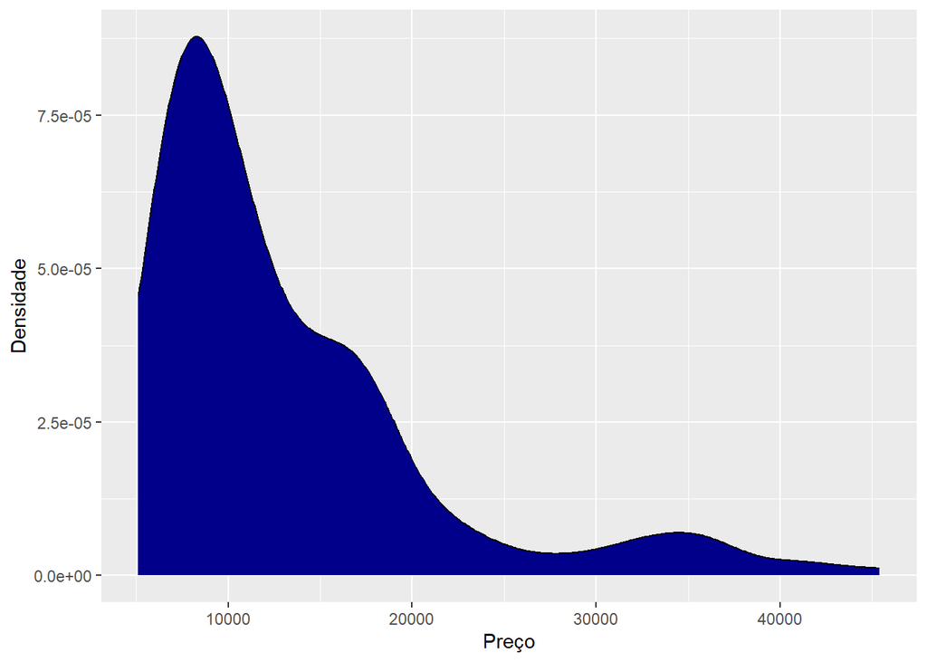

```r
library(ggplot2)
dados %>% ggplot(aes(price))+
  geom_density(fill = "darkblue")+
  labs(x= "Preço", y="Densidade")
```

```r
shapiro.test(dados$price)
```

```
##
##  Shapiro-Wilk normality test
##
## data:  dados$price
## W = 0.79542, p-value = 1.145e-15
```

Pelo teste de normalidade univariada de Shapiro-Wilk, o valor deu menor que 0.05, então os dados de preço não seguem a normalidade dos resíduos.

### Vendo as Correlações das Variáveis Númericas

Problemas de multicolinearidade são muitos comuns em modelos de regressão,isso acaba prejudicando o modelo, devido a este fato vamos verificar a correção entre as variáveis preditoras, e depois vamos verificar quais variaveis remover, para verificar a correlação vamos executar o gráfico de correlação de pearson através do comando abaixo:

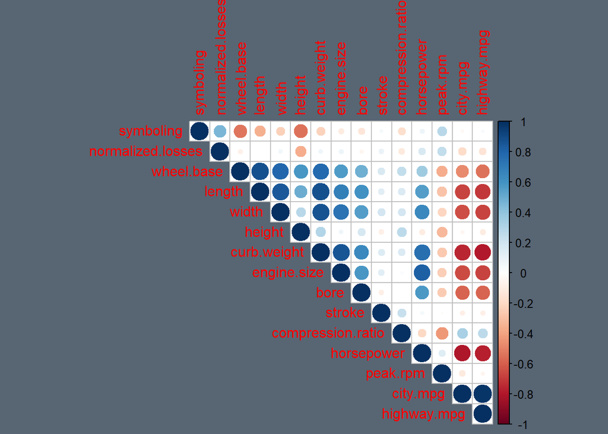

```r
library(corrplot)
par(bg = '#586573')
dados[-26] |>
  dplyr::select(where(is.numeric))  |>
  cor( ) |>
corrplot::corrplot( type = "upper")
```

Como podemos ver várias colunas apresentaram correlação,logo teremos que remove-lás

### Verificando Presença de Multicolinearidade das Variáveis Númericas

```r
library(caret)

t<-dados[-26] |>
  dplyr::select(where(is.numeric))

 t %>%
  cor() %>%
  findCorrelation( cutoff = .50, verbose = FALSE)
```

```
## [1]  7  4  5  3 15 14  8  9  6
```

Logo, essas as variáveis cotadas para remoção ,mas antes disso vamos ver se temos colunas com repetidas

### Verificando se Temos Colunas Identicas

```r
t %>%
  cor() %>%  findLinearCombos ()
```

```
## $linearCombos
## list()
##
## $remove
## NULL
```

Como podemos ver não temos colunas repetidas , vamos remover as colunas sugeridas

```r
t<-dados |>
  dplyr::select(where(is.numeric))

library(tidyverse)
novo<-dados %>%
  dplyr::select(symboling,normalized.losses,compression.ratio,horsepower,peak.rpm,price )

nov1<-dados |>
  dplyr::select(where(is.factor))


#unido os dados

 novo<-cbind(nov1,novo)
#
# glimpse(novo)
# novo<-novo |>
#   dplyr::filter(make !="?" , fuel.type !="?",aspiration  !="?" ,
#                 num.of.doors !="?", engine.type !="l")


write.csv(novo,"carros2Trat.csv",row.names = F)
```

Agora podemos proseguir para criação do nosso modelo

# Criando o Modelo MLG

Após a remoção das variáveis com problemas de multicolinearidade vamos criar o primeiro modelo utilizando todas as variáveis, o segundo modelo recebera as variaveis selecionadas ,

```r
# nv<- novo[11:16]
#
mod<-glm(price~.,family = Gamma(link=log),data = novo)



summary(mod)
```

```
##
## Call:
## glm(formula = price ~ ., family = Gamma(link = log), data = novo)
##
## Coefficients: (4 not defined because of singularities)
##                          Estimate Std. Error t value Pr(>|t|)
## (Intercept)             8.936e+00  8.993e-01   9.936  < 2e-16 ***
## makeaudi                7.479e-02  1.909e-01   0.392  0.69574
## makebmw                 3.048e-01  1.641e-01   1.857  0.06518 .
## makechevrolet          -2.188e-01  1.661e-01  -1.317  0.18979
## makedodge              -2.231e-01  1.449e-01  -1.540  0.12561
## makehonda               9.886e-02  1.749e-01   0.565  0.57277
## makeisuzu               5.642e-02  1.524e-01   0.370  0.71180
## makejaguar              3.832e-01  1.688e-01   2.270  0.02462 *
## makemazda              -2.474e-03  1.299e-01  -0.019  0.98484
## makemercedes-benz       2.951e-01  1.913e-01   1.543  0.12494
## makemercury            -1.804e-01  2.092e-01  -0.862  0.38991
## makemitsubishi         -2.138e-01  1.493e-01  -1.431  0.15439
## makenissan             -1.617e-01  1.314e-01  -1.231  0.22019
## makepeugot              4.504e-01  2.868e-01   1.571  0.11835
## makeplymouth           -2.327e-01  1.446e-01  -1.610  0.10955
## makeporsche             2.835e-01  2.167e-01   1.308  0.19289
## makerenault            -1.315e-01  1.734e-01  -0.758  0.44951
## makesaab                1.190e-01  1.558e-01   0.764  0.44602
## makesubaru             -8.006e-02  1.281e-01  -0.625  0.53286
## maketoyota             -1.594e-01  1.172e-01  -1.360  0.17579
## makevolkswagen         -1.119e-01  1.439e-01  -0.778  0.43779
## makevolvo               1.163e-01  1.439e-01   0.808  0.42017
## fuel.typegas           -6.888e-02  5.337e-01  -0.129  0.89747
## aspirationturbo        -1.011e-02  5.415e-02  -0.187  0.85215
## num.of.doorsNA         -7.357e-02  1.210e-01  -0.608  0.54403
## num.of.doorstwo        -9.946e-02  4.049e-02  -2.456  0.01516 *
## body.stylehardtop      -2.571e-01  9.214e-02  -2.790  0.00595 **
## body.stylehatchback    -2.853e-01  8.506e-02  -3.354  0.00101 **
## body.stylesedan        -2.653e-01  9.082e-02  -2.922  0.00401 **
## body.stylewagon        -2.294e-01  9.757e-02  -2.351  0.01998 *
## drive.wheelsfwd        -3.528e-02  6.439e-02  -0.548  0.58462
## drive.wheelsrwd         2.387e-02  9.194e-02   0.260  0.79551
## engine.locationrear    -5.082e-02  2.079e-01  -0.245  0.80717
## engine.typedohcv       -2.070e+00  3.198e-01  -6.473 1.25e-09 ***
```

[output cut: 18 more lines]

```
## symboling              -5.497e-03  1.921e-02  -0.286  0.77512
## normalized.losses       8.927e-04  5.872e-04   1.520  0.13050
## compression.ratio       2.900e-02  3.820e-02   0.759  0.44893
## horsepower              7.760e-03  1.232e-03   6.300 3.05e-09 ***
## peak.rpm               -6.649e-05  4.549e-05  -1.462  0.14593
## ---
## Signif. codes:  0 '***' 0.001 '**' 0.01 '*' 0.05 '.' 0.1 ' ' 1
##
## (Dispersion parameter for Gamma family taken to be 0.02232896)
##
##     Null deviance: 55.8608  on 204  degrees of freedom
## Residual deviance:  3.4983  on 152  degrees of freedom
## AIC: 3688.5
##
## Number of Fisher Scoring iterations: 6
```

```r
library(hnp)

hnp(mod$residuals, sim = 99,resid.type ='deviance',how.many.out=T ,conf = 0.95,scale = T)
```

```
## Half-normal plot with simulated envelope generated assuming the residuals are
##         normally distributed under the null hypothesis.
## Estimated mean: -1.672731e-11
## Estimated variance: 0.01663726
```

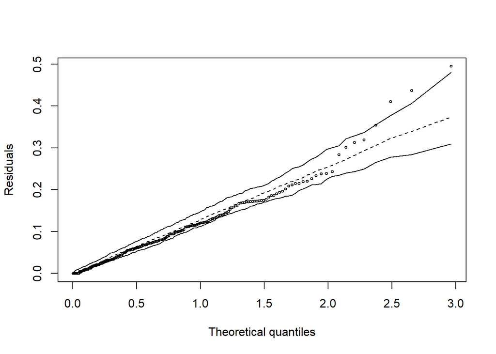

```
## Total points: 205
## Points out of envelope: 17 ( 8.29 %)
```

Podemos ver que várias covariáveis não apresentaram significância , logo não são importantes para o modelo.

## Verificando a Importancia das Variáveis para o Modelo

Vamos verificar quais variáveis são mais importantes para o modelo , para isso vamos utilizar o pacote e os comandos abaixo:

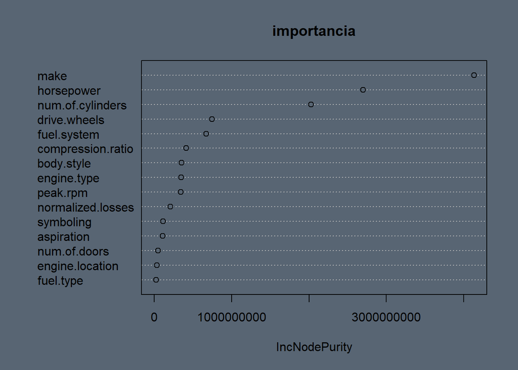

```r
library(randomForest)
importancia  = randomForest(price ~ ., data = novo)

col = importance(importancia)
options(scipen=999)
par(bg = '#586573')
varImpPlot(importancia)
```

```r
mod2<-glm(price~make+horsepower+num.of.cylinders+drive.wheels+fuel.system+
      compression.ratio+engine.type+body.style+peak.rpm,family = poisson(link=log), data = novo)

mod3<-glm(price~make+horsepower+num.of.cylinders+drive.wheels+fuel.system+
      compression.ratio+engine.type+body.style+peak.rpm,family = poisson(link = "identity"), data = novo)
summary(mod2)
```

```
##
## Call:
## glm(formula = price ~ make + horsepower + num.of.cylinders +
##     drive.wheels + fuel.system + compression.ratio + engine.type +
##     body.style + peak.rpm, family = poisson(link = log), data = novo)
##
## Coefficients: (2 not defined because of singularities)
##                            Estimate   Std. Error  z value             Pr(>|z|)
## (Intercept)             8.599989781  0.027282615  315.219 < 0.0000000000000002
## makeaudi                0.111896580  0.009599429   11.657 < 0.0000000000000002
## makebmw                 0.311709040  0.008201290   38.007 < 0.0000000000000002
## makechevrolet          -0.242616865  0.011059823  -21.937 < 0.0000000000000002
## makedodge              -0.198311007  0.007849682  -25.264 < 0.0000000000000002
## makehonda               0.057678298  0.009589423    6.015         0.0000000018
## makeisuzu               0.020339743  0.008826892    2.304               0.0212
## makejaguar              0.426957585  0.007635960   55.914 < 0.0000000000000002
## makemazda               0.056770483  0.006756141    8.403 < 0.0000000000000002
## makemercedes-benz       0.306254635  0.010012874   30.586 < 0.0000000000000002
## makemercury            -0.159234844  0.010591711  -15.034 < 0.0000000000000002
## makemitsubishi         -0.167616358  0.007912198  -21.185 < 0.0000000000000002
## makenissan             -0.162770163  0.006455624  -25.214 < 0.0000000000000002
## makepeugot              0.247134792  0.007037687   35.116 < 0.0000000000000002
## makeplymouth           -0.197842030  0.007998469  -24.735 < 0.0000000000000002
## makeporsche             0.322668636  0.010091354   31.975 < 0.0000000000000002
## makerenault            -0.117702083  0.009970126  -11.805 < 0.0000000000000002
## makesaab                0.141302169  0.007574683   18.655 < 0.0000000000000002
## makesubaru              0.126280590  0.011543083   10.940 < 0.0000000000000002
## maketoyota             -0.147115459  0.006000961  -24.515 < 0.0000000000000002
## makevolkswagen         -0.104486641  0.007305208  -14.303 < 0.0000000000000002
## makevolvo               0.106172779  0.007034977   15.092 < 0.0000000000000002
## horsepower              0.007242602  0.000062068  116.688 < 0.0000000000000002
## num.of.cylindersfive   -0.210698466  0.007575458  -27.813 < 0.0000000000000002
## num.of.cylindersfour   -0.377190201  0.010028232  -37.613 < 0.0000000000000002
## num.of.cylinderssix    -0.242827465  0.009574378  -25.362 < 0.0000000000000002
## num.of.cylindersthree  -0.286702002  0.019473119  -14.723 < 0.0000000000000002
## num.of.cylinderstwelve -0.950396532  0.019263854  -49.336 < 0.0000000000000002
## num.of.cylinderstwo    -0.258475545  0.013644402  -18.944 < 0.0000000000000002
## drive.wheelsfwd         0.040331337  0.004266027    9.454 < 0.0000000000000002
## drive.wheelsrwd         0.119977038  0.005419622   22.138 < 0.0000000000000002
## fuel.system2bbl         0.150430822  0.007688549   19.566 < 0.0000000000000002
```

[output cut: 64 more lines]

```
## body.stylehardtop      ***
## body.stylehatchback    ***
## body.stylesedan        ***
## body.stylewagon        ***
## peak.rpm               ***
## ---
## Signif. codes:  0 '***' 0.001 '**' 0.01 '*' 0.05 '.' 0.1 ' ' 1
##
## (Dispersion parameter for poisson family taken to be 1)
##
##     Null deviance: 795654  on 204  degrees of freedom
## Residual deviance:  45909  on 157  degrees of freedom
## AIC: 48298
##
## Number of Fisher Scoring iterations: 4
```

```r
require(MASS)
mod.nb <- glm.nb(price~make+horsepower+num.of.cylinders+drive.wheels+fuel.system+
      compression.ratio+engine.type+body.style+peak.rpm, data = novo)

summary(mod.nb)
```

```
##
## Call:
## glm.nb(formula = price ~ make + horsepower + num.of.cylinders +
##     drive.wheels + fuel.system + compression.ratio + engine.type +
##     body.style + peak.rpm, data = novo, init.theta = 55.80747951,
##     link = log)
##
## Coefficients: (2 not defined because of singularities)
##                           Estimate  Std. Error z value             Pr(>|z|)
## (Intercept)             8.79835966  0.41677739  21.110 < 0.0000000000000002 ***
## makeaudi                0.13116155  0.15580354   0.842             0.399878
## makebmw                 0.34519491  0.14181125   2.434             0.014925 *
## makechevrolet          -0.20880626  0.14786572  -1.412             0.157910
## makedodge              -0.17001056  0.12272736  -1.385             0.165970
## makehonda               0.08841187  0.15337067   0.576             0.564305
## makeisuzu               0.06961627  0.13404656   0.519             0.603521
## makejaguar              0.44425078  0.14794902   3.003             0.002676 **
## makemazda               0.04308152  0.11209611   0.384             0.700736
## makemercedes-benz       0.34040852  0.16848376   2.020             0.043339 *
## makemercury            -0.17810096  0.18515733  -0.962             0.336105
## makemitsubishi         -0.15358064  0.12302197  -1.248             0.211885
## makenissan             -0.12656463  0.11026587  -1.148             0.251046
## makepeugot              0.26404075  0.11584148   2.279             0.022648 *
## makeplymouth           -0.16752495  0.12376214  -1.354             0.175863
## makeporsche             0.33856970  0.18681740   1.812             0.069939 .
## makerenault            -0.10079073  0.14898733  -0.677             0.498720
## makesaab                0.14446412  0.12743172   1.134             0.256938
## makesubaru              0.03563941  0.21271377   0.168             0.866940
## maketoyota             -0.11921589  0.10261982  -1.162             0.245348
## makevolkswagen         -0.07749529  0.11849432  -0.654             0.513112
## makevolvo               0.14672953  0.12322939   1.191             0.233770
## horsepower              0.00773946  0.00100668   7.688   0.0000000000000149 ***
## num.of.cylindersfive   -0.17449136  0.14183460  -1.230             0.218605
## num.of.cylindersfour   -0.32705301  0.17426158  -1.877             0.060546 .
## num.of.cylinderssix    -0.23271201  0.16482381  -1.412             0.157984
## num.of.cylindersthree  -0.24917799  0.24319743  -1.025             0.305556
## num.of.cylinderstwelve -0.96313530  0.32715430  -2.944             0.003240 **
## num.of.cylinderstwo    -0.16648732  0.22719871  -0.733             0.463691
## drive.wheelsfwd        -0.03846467  0.05739835  -0.670             0.502771
## drive.wheelsrwd         0.02559218  0.07507070   0.341             0.733173
```

[output cut: 20 more lines]

```
## Signif. codes:  0 '***' 0.001 '**' 0.01 '*' 0.05 '.' 0.1 ' ' 1
##
## (Dispersion parameter for Negative Binomial(55.8075) family taken to be 1)
##
##     Null deviance: 3104.01  on 204  degrees of freedom
## Residual deviance:  205.57  on 157  degrees of freedom
## AIC: 3690.2
##
## Number of Fisher Scoring iterations: 1
##
##
##               Theta:  55.81
##           Std. Err.:  5.52
##
##  2 x log-likelihood:  -3592.229
```

```r
library(DescTools)
PseudoR2(mod2)
```

```
##  McFadden
## 0.9395923
```

```r
PseudoR2(mod3)
```

```
##  McFadden
## 0.9350685
```

```r
hnp(mod2, sim = 99,resid.type ='deviance',how.many.out=T ,conf = 0.95,scale = T)
```

```
## Poisson model
```

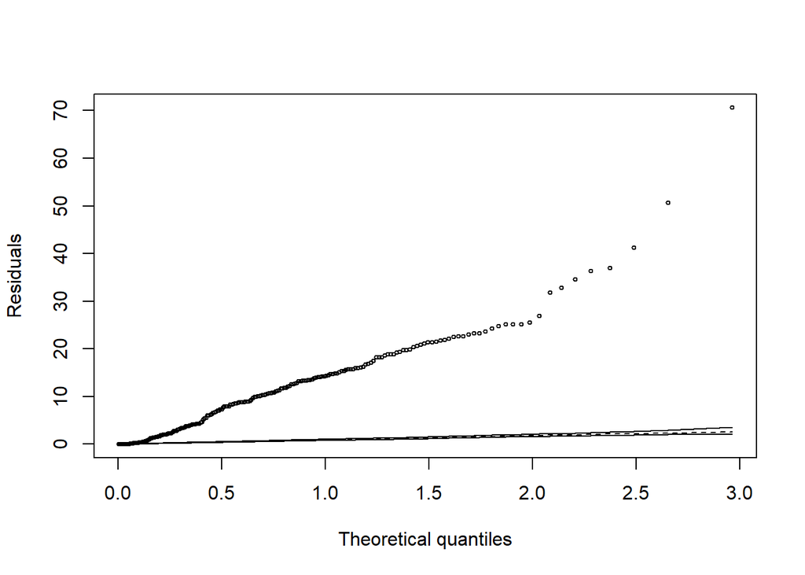

```
## Total points: 205
## Points out of envelope: 197 ( 96.1 %)
```

```r
mod2<-glm(price~make+horsepower+num.of.cylinders+fuel.system+
      compression.ratio+body.style+engine.type,poisson(link = "log"), data = novo)

require(hnp)
hnp(mod2, sim = 99,resid.type ='deviance',how.many.out=T ,conf = 0.95,scale = T)
```

```
## Poisson model
```

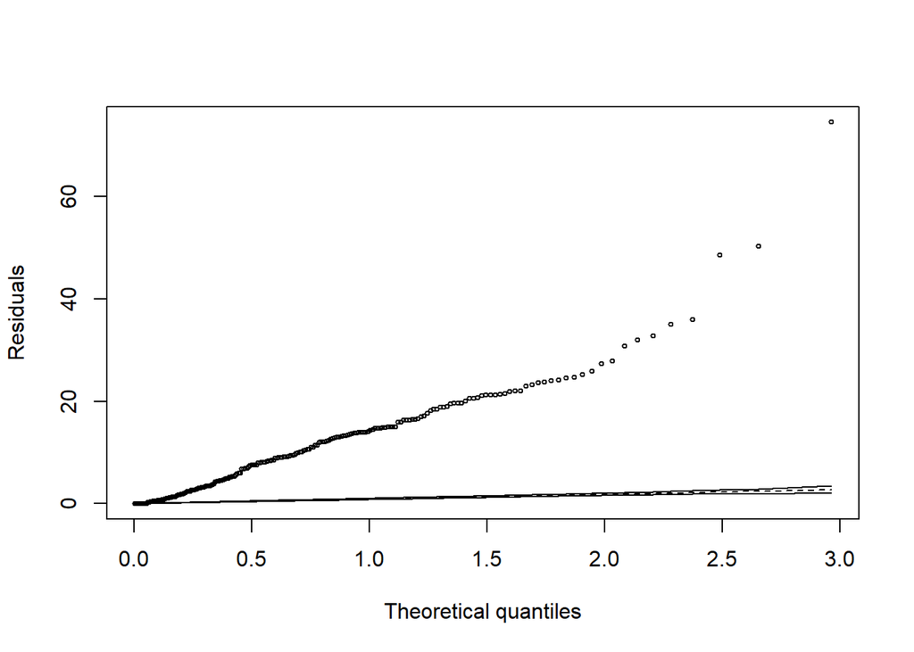

```
## Total points: 205
## Points out of envelope: 197 ( 96.1 %)
```

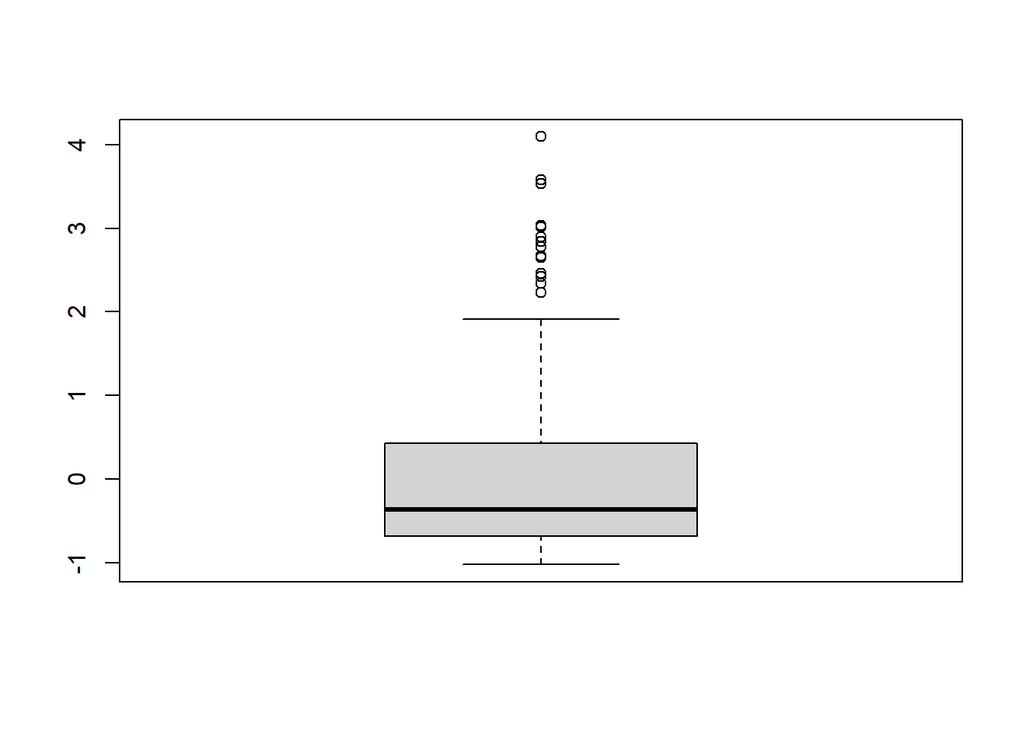

```r
# trabalhando com o preço transformado
novo2<-novo


novo2$price<-log(novo$price)


mod2<-glm(price~make+horsepower+num.of.cylinders+drive.wheels+fuel.system+
      compression.ratio+engine.type+body.style+peak.rpm,family = poisson(link = "log"), data = novo2)



boxplot(scale(novo$price))
```

```r
# library(hnp)
#
# ajuste = c('mod', 'mod2','mod3','yu','yu2','mod.nb')
# aic    = c(AIC(mod),AIC(mod2),AIC(mod3),AIC(yu),AIC(yu2),AIC(mod.nb))
# deviance    = c(deviance(mod),deviance(mod2),deviance(mod3),deviance(yu),deviance(yu2),deviance(mod.nb))
# #verossimilhanca = c(logLik(glmod1),logLik(glmod2),logLik(glmod3))
# df<-data.frame(ajuste, round(aic,2),round(deviance,2))
# colnames(df)=c("ajuste","AIC","Deveiance")
#
# df%>% datatable()
```

# Conclusão

## Exibindo os Coeficientes do Nosso Modelo

```r
mod.nb$coefficients
```

```
##            (Intercept)               makeaudi                makebmw
##          8.79835966468          0.13116154829          0.34519490940
##          makechevrolet              makedodge              makehonda
##         -0.20880625808         -0.17001056059          0.08841187181
##              makeisuzu             makejaguar              makemazda
##          0.06961626631          0.44425078314          0.04308151936
##      makemercedes-benz            makemercury         makemitsubishi
##          0.34040852392         -0.17810095605         -0.15358063612
##             makenissan             makepeugot           makeplymouth
##         -0.12656463271          0.26404075244         -0.16752495142
##            makeporsche            makerenault               makesaab
##          0.33856969754         -0.10079072800          0.14446411950
##             makesubaru             maketoyota         makevolkswagen
##          0.03563941091         -0.11921589353         -0.07749528883
##              makevolvo             horsepower   num.of.cylindersfive
##          0.14672952991          0.00773946094         -0.17449135722
##   num.of.cylindersfour    num.of.cylinderssix  num.of.cylindersthree
##         -0.32705301182         -0.23271201022         -0.24917798538
## num.of.cylinderstwelve    num.of.cylinderstwo        drive.wheelsfwd
##         -0.96313530290         -0.16648731553         -0.03846466709
##        drive.wheelsrwd        fuel.system2bbl        fuel.system4bbl
##          0.02559218388          0.14890735214          0.26369701884
##         fuel.systemidi         fuel.systemmfi        fuel.systemmpfi
##         -0.07183705245          0.33651929424          0.25378916141
##        fuel.systemspdi        fuel.systemspfi      compression.ratio
##          0.26887554718          0.21949845730          0.03594574628
##       engine.typedohcv           engine.typel         engine.typeohc
##         -2.10347770493                     NA          0.10666777474
##        engine.typeohcf        engine.typeohcv       engine.typerotor
##         -0.09658218985          0.02002224056                     NA
##      body.stylehardtop    body.stylehatchback        body.stylesedan
##         -0.25723096158         -0.26384494358         -0.18263531574
##        body.stylewagon               peak.rpm
##         -0.15278278671         -0.00006921681
```

# Referências

O primeiro automóvel-INFO.Escola , acessado em 10/10/2022 https://www.infoescola.com/curiosidades/historia-do-automovel/

1985 Modelo de Importação de Carro e Especificações de Caminhão, Anuário Automotivo de 1985 Ward.

Personal Auto Manuals, Insurance Services Office, 160 Water Street, Nova York, NY 10038

Insurance Collision Report, Insurance Institute for Highway Safety, Watergate 600, Washington, DC 20037

dados veículos- IBGE ,acessado em 09/10/2022 https://cidades.ibge.gov.br/brasil/pesquisa/22/28120